# Introdução à Ciência de Dados

Mestrado Profissional em Administração

Prof. Washington Santos da Silva

IFMG - Campus Formiga

5 de junho de 2025

## Diário de Bordo

**O que vimos até aqui?**

- Aula 1 ✅
  - Apresentação da Disciplina ✅
  - Introdução e Contextualização ✅
  - O que é Ciência de Dados? ✅
  - Pesquisa Reproduzível e Ciência de Dados ✅
  - Papéis Profissionais ✅
  - Aplicações ✅
  - Habilidades Interpessoais e Analíticas ✅
  - Apresentação da Disciplina ✅
  - Configurações: Git/GitHub ✅
- Aula 2 ✅
  - Metodologia CRISP-DM ✅
  - Tipos de Análise de Dados ✅
  - Introdução ao RStudio e criação do **seu** Projeto da Disciplina ✅
  - Introdução ao Sistema de Publicação Quarto ✅
  - Introdução ao Git e GitHub: controle de versão e criação do **seu** repositório no GitHub ✅
- Aula 3 ✅
  - Breve Revisão sobre o RStudio ✅
  - Sistema de Publicação Quarto: (Cont.) ✅
  - Introdução ao Git e GitHub: (Cont.) ✅
  - Sessão Prática: Fluxo de trabalho integrando RStudio/Quarto/R/Git/GitHub ✅
- Aula 4 ✅
  - Conceitos de Variáveis e Observações em Estatística ✅
  - Conceito de Dados Organizados (*Tidy Data*) ✅
  - Tipos atômicos e classes principais de dados da linguagem R ✅
  - Tipos de Dados Tradicionais em Finanças: ✅
    - Dados em Secção-Cruzada (ou Transversal) (*Cross-Section Data*) ✅
    - Dados em Secções-Cruzadas Combinadas (*Pooled Cross-Section Data*) ✅
    - Dados em Séries Temporais (*Time Series Data*) ✅
    - Dados em Painel (ou Longitudinais) (*Panel Data*) ✅
  - Importação e Preparação de Dados Típicos de Finanças com exemplos práticos ✅
- Aula 5 ✅
  - Metodologia CRISP-DM: Fases 2 e 3 ✅
  - Revisão sobre Dados Organizados (*Tidy Data*) ✅
  - Introdução ao Pacote tidyr: função pivot_longer() ✅
  - Introdução ao Pacote dplyr: funções select() e filter() ✅
  - Exercícios ✅
- Aula 6 ✅
  - Função mutate ✅
  - Funções group_by e summarize ✅
  - Exercícios ✅
- Aula 7 ✅
  - Introdução ao Pacote dplyr: Tipos Básicos de *joins* ✅
  - Exercícios ✅

## Nesta Aula

**Tópicos - Fundamentos de Probabilidade e Simulação**

- Modelos
- Conceitos Fundamentais de Probabilidade
  - O que é Probabilidade?
  - Probabilidade Condicional e Independência
  - Amostra Aleatória
  - Variáveis Aleatórias e Funções de Probabilidade
  - Função de Distribuição Acumulada
  - Lei dos Grandes Números
- Distribuições de Probabilidade de VA Discretas
  - Distribuição de Bernoulli
  - Características de uma Distribuição de Probabilidade
    - Valor Esperado
    - Variância e Desvio-Padrão
    - Assimetria e Curtose
  - Distribuição Binomial
- Distribuições de Probabilidade de VA Contínuas
  - Teorema Central do Limite
  - Distribuição Normal
- Aplicação
  - Valor-em-Risco (VaR)

**Diretrizes para Aulas Mais Produtivas**

⌨️ **Código com método:**

95% dos erros são evitáveis com:

- Atenção na digitação
- Respeitar a sequência lógica de etapas
- Revisão antes de pedir ajuda

🤝 **Inteligência colaborativa:**

- Compartilhe conhecimento
- Resolva questões técnicas simples com colegas próximos
- Reserve ao professor as dúvidas conceituais complexas

💪 **Capacidade de Resolver Problemas**

Cada erro resolvido é uma evolução da sua habilidade analítica

## Metodologia CRISP-DM

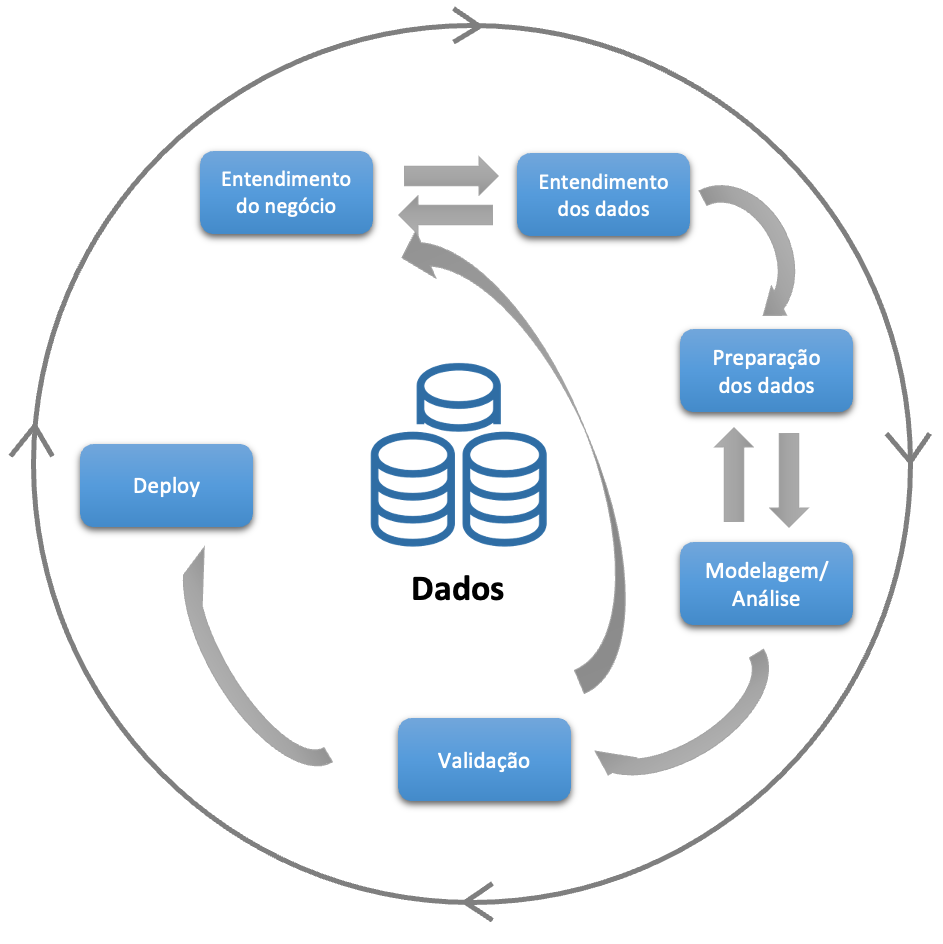

Fases da Metodologia CRISP-DM

## CRISP-DM: Onde Estamos?

**Contexto na Disciplina**

Até agora, vimos as fases 1, 2 e 3 da Metodologia CRISP-DM e como usar a linguagem R e os pacotes do tidyverse para executar essas fases:

- **Fase 1 (Entendimento do Negócio)**: Relatório Junglivet
- **Fase 2 (Entendimento dos Dados)**: Exploração inicial com dplyr
- **Fase 3 (Preparação dos Dados)**: Limpeza e transformação com tidyverse

Nesta e na próxima aula, vamos ver que a teoria da probabilidade é o fundamento da **Fase 4** que envolve análise e modelação de dados.

# Modelos

## Modelos

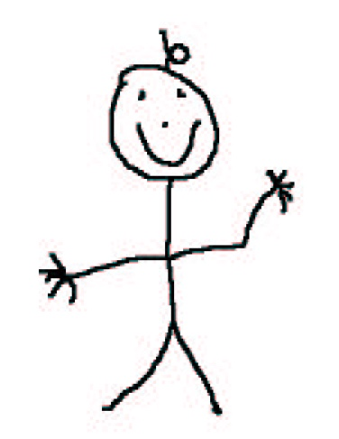

**O que é um Modelo?**

Agora você sabe o que é um **modelo**: uma **abstração**

- Este modelo é *verdadeiro* ou *falso*? Pergunta maluca!
- Os modelos são **realistas ou não**? Faz sentido para características de um fenômeno real que nos interessam
- Os modelos são **úteis** ou **não**? Sempre uma boa pergunta!

## Modelos Estatísticos: Notação

**Notação Básica**

- Variável **Dependente**:
  - $Y$ é $n \times 1$
  - $Y_i$ é uma variável aleatória (antes de observarmos)
  - $y_i$ é um número (depois de observarmos)
- Variáveis **Explicativas**:
  - aka covariáveis, variáveis independentes ou exógenas.
  - $X = {x_{ij}}$ é $n \times k$ (observações por variáveis)
  - Um conjunto de colunas (variáveis): $X = {x_1,\ldots,x_k}$
  - Linha (obsevação) $i$: ${x_{i1},\ldots,x_{ik}}$

## Modelos Estatísticos: Notação

Alguns nomes alternativos para $y$ e $x$:

[output not shown]

## Modelos de Regressão: Notações

**Notação de Regressão**

Notação Padrão:

$$\begin{align*}
Y_i &= x_i\beta + \epsilon_i = \text{sistemática} + \text{aleatória} \\
\epsilon_i &\sim N(0,\sigma^2)
\end{align*}$$

Notação Alterantiva:

$$\begin{align*}
Y_i &\sim N(\mu_i,\sigma^2) \,\,\,\, \text{aleatória ou estocástica} \\
\mu_i &= x_i\beta. \,\,\,\,\,\,\,\,\,\,\,\,\,\, \text{sistemática}
\end{align*}$$

## Notação Alternativa Generalizada

**Descrição**

$$\begin{align*}
Y_i &\sim f(\theta_i,\alpha) \,\,\,\, \text{estocástica} \\
\theta_i &= g(x_i,\beta) \,\,\,\, \text{sistemática}
\end{align*}$$

sendo:

- $Y_i$ = variável aleatória de interesse.
- $f(\cdot)$ = funçào densidade de probabilidade.
- $\theta_i$ = uma característica sistemática da densidade ($f()$) que varia para cada $i$.
- $\alpha$ = característica da densidade ($f()$) constante para cada $i$.
- $g(\cdot)$ = forma funcional.
- $x_i$ = vetor de variáveis explicativas para $i$.
- $\beta$ = parâmetros de efeitos.

## Formas de Incerteza

**Incertezas em Modelos Estatísticos**

$$\begin{align*}
Y_i &\sim f(\theta_i,\alpha) \,\,\,\, \text{estocástica} \\
\theta_i &= g(x_i,\beta) \,\,\,\, \text{sistemática}
\end{align*}$$

- **Incerteza das estimativas**: falta de conhecimento de $\beta$ e $\alpha$. Desaparece à medida que $n$ aumenta.
- **Incerteza fundamental**: Representada pelo componente estocástico (existe não importa o que você faça ou o tamanho de $n$).
- **Dependência do modelo**: talvez toda a especificação esteja errada?

## Componentes Sistemático

**Procedimento padrão:**

- **Use teoria**: suponha uma classe de formas funcionais.
- **Use dados**: Estime os valores dos parâmetros (para selecionar um membro da classe)
- **Incerteza permanece**: por causa de 1) incerteza das estimativas, 2) incerteza fundamental e 3) dependência do modelo.

Se escolhermos a família errada de formas funcionais:

- Temos **erro de especificação** e potencialmente **viés**.
- Ainda obtemos a melhor aproximação [linear, logit, etc] para a forma funcional correta.
- Pode estar próximo ou longe da verdade.

## Componentes Sistemático: Exemplos

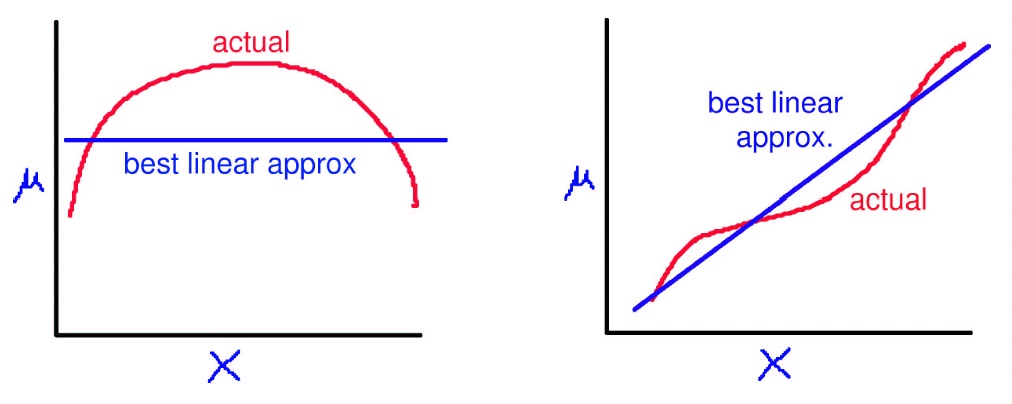

## Visão Geral: Componentes Estocásticos

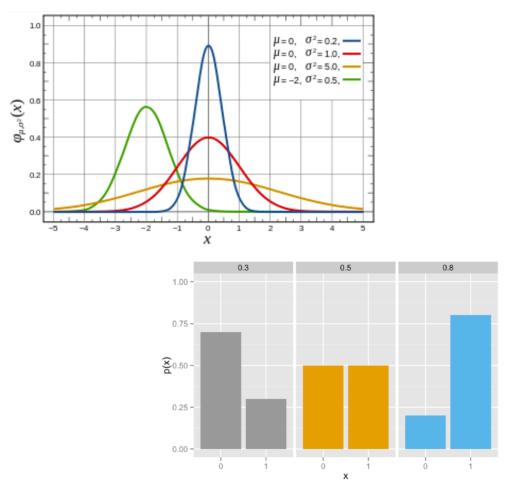

## Escolhendo os Componentes Sistemático e Estocástico

**Escolhendo os Componentes**

Todas as decisões de modelagem são sobre o **Processo Gerador dos Dados** (PGD):

- A cadeia de evidências do mundo até a nossa observação dele.
- A primeira pergunta que você faz em todo trabalho empírico.

E se não conhecermos o DGP (e normalmente não conhecemos)?

- O problema: dependência do modelo
- Nossa primeira abordagem: fazer suposições “razoáveis” e verificar o ajuste (e outras implicações observáveis das suposições).

## Processo Gerador dos Dados (com simulação)

**Processo Gerador dos Dados (PGD)**

- Incerteza sobre o PGD ⇝ Incerteza Substantiva
- Para que os dados sejam úteis, você precisa do PGD.
- A teoria é útil para os dados; os dados são úteis para a teoria.

Como usaremos os PGDs?

- Probabilidade: **Assume o Processo Gerador dos Dados**
- Inferência Estatística: **Aprende o Processo Gerador dos Dados**

## O que é Simulação?

**Amostragem** (*survey sampling*):

1. Aprende sobre uma população tomando uma amostra aleatória desta população
2. Usa amostras aleatórias para estimar uma característica da população
3. A estimativa é arbitrariamente precisa para $n$ grande.
4. Exemplo: estimar a média da população.

**Simulação**:

1. Aprende sobre uma distribuição de probabilidade gerando amostras (pseudo-)aleatórias desta distribuição.
2. Usa as amostras aleatórias para aproximar uma característica da distribuição de probabilidades.
3. A aproximação é arbitrariamente precisa para *n* grande.
4. Exemplo: Aproximar o valor esperado (média) de uma distribuição de probabilidades.

## Simulação de Monte Carlo

**O que é Simulação?**

Simulação é usada para:

1. **Entender** o processo gerador dos dados assumido.
2. **Resolver** problemas envolvendo probabilidades.
3. **Avaliar** estimadores.
4. **Estimar** características de funções densidade de probabilidade.
5. Transformar resultados estatísticos em quantidades de interesse.
6. Obter uma resposta correta: mais fácil que cálculos matemáticos.

## Por que precisamos de probabilidade para construir modelos?

**Por que Probabilidade é Essencial?**

- Modelos lidam com incerteza (componente estocástico)
- Probabilidade fornece as ferramentas para quantificar essa incerteza
- Em finanças, praticamente todos os fenômenos envolvem aleatoriedade (somente em finanças?)

# Conceitos Fundamentais de Probabilidade

## Conceitos Essenciais

**Experimento Aleatório**

*Processo* ou *fenômeno* com resultados incertos, ou seja, não podemos prever o resultado com certeza, mas podemos descrever os possíveis resultados e suas probabilidades.

**Por que “experimento”?**

- Termo herdado da física/estatística clássica
- Implica *repetibilidade* (condições controláveis)

**Sinônimos válidos**: Processo estocástico, fenômeno aleatório

**Exemplos de “Experimentos” Aleatórios**:

- Variação diária da taxa de câmbio Real/Dólar -> $S = (0, +\infty)$
- Preço diário da saca de soja no Brasil -> $S = (0, +\infty)$
- Retorno de uma ação na B3 -> $S = (-\infty, +\infty)$
- Taxa de inadimplência de crédito em uma instituição financeira -> $S = [0, 1]$ (0% a 100%)

**Espaço Amostral (S)**

Conjunto de *todos* os resultados possíveis de um processo aleatório.

- “Retorno ≥ 5%” → $A = [0.05, +\infty)$ (subconjunto de $S$)
- “Default” → $B = \{Sim\}$ (subconjunto de $\{Sim, Não\}$)

**Evento**

Subconjunto não vazio do espaço amostral ($S$), representando *perguntas mensuráveis* sobre o fenômeno.

**Exemplos**:

- *Mercado financeiro*:
  - “Ação valorizar ≥5% amanhã” → $A = [0.05, +\infty) \subset S$
  - “Taxa SELIC cair no próximo mês” → $B = \{Sim\} \subset \{Sim, Não\}$
- *Crédito*:
  - “Inadimplência em até 2 anos” → $C = (0, 24] \subset S$ (meses)

> *Próximo passo*: Como *quantificar a probabilidade* desses eventos ocorrerem?

## Interpretações da Probabilidade

**Interpretações**

- **Probabilidade Clássica (ou a priori)**

Funciona como uma “contagem justa” em situações equilibradas:

$$P(A) = \frac{\text{casos favoráveis}}{\text{casos possíveis}}$$

**Exemplo**: No dado não viciado, sair par tem 3 casos favoráveis (2,4,6) em 6 possíveis

$$P = \frac{3}{6} = \frac{1}{2}$$

⚠️ **Limitações?**

- *Sem simetria*: Se o dado for viciado, os lados não têm a mesma chance
- *Casos infinitos*: Como medir a probabilidade de um número aleatório entre 0 e 1 ser menor que 0.5? Há infinitas possibilidades!
- **Probabilidade Frequentista**

“A Probabilidade de um evento A ocorrer em n repetições de um experimento é aproximadamente a frequência relativa de A”:

$$P(A) \approx \frac{\text{vezes que A ocorreu}}{\text{nº total de repetições}} \quad \text{(para muitas tentativas)}$$

**Exemplo**:

- Em 10.000 lançamentos de moeda, saíram 4.983 caras → $P(\text{cara}) \approx 0.4983$.
- Hospitais calculam mortalidade cirúrgica acompanhando resultados históricos.

🔍 A *lei dos grandes números* garante que essa aproximação melhora conforme aumentamos as repetições.

- Fundamento da escola **frequentista** de estatística.
- **Probabilidade Subjetiva**

“Probabilidade como grau de crença pessoal, atualizável com novas informações”:

**Como funciona?**

1. Começa com uma “aposta inicial” (prior)
2. Coleta dados novos
3. Ajusta a crença usando matemática (Teorema de Bayes)

**Exemplos**:

- Meteorologia: “70% de chuva” combina modelos e observações atuais
- Medicina: Diagnósticos são ajustados conforme exames chegam
- Fundamento da escola **bayesiana** de estatística

💡 **Vantagem**: Única abordagem aplicável a eventos únicos

## O que é Probabilidade?

**Abordagem Matemática da Probabilidade**

Kolmogorov unificou as interpretações através de 3 axiomas que toda função de probabilidade deve satisfazer, independentemente de sua interpretação:

1. $P(A) \geq 0$ para qualquer evento $A$
2. $P(S) = 1$ onde $S$ é o espaço amostral
- Os axiomas 1 e 2 implicam que $0 \leq P(A) \leq 1$ para qualquer evento $A$.
3. Para eventos mutuamente exclusivos $A_1, A_2, \ldots$:

   $P\left(\bigcup_{i=1}^\infty A_i\right) = \sum_{i=1}^\infty P(A_i)$

Todos os teoremas posteriores da teoria da probabilidade são derivados desses axiomas.

## Probabilidade

**Conceitos Fundamentais**

- **Probabilidade Condicional**

Sejam $A$ e $B$ dois eventos com $P(B) > 0$. A probabilidade de $A$ ocorrer dado que $B$ ocorreu é:

$$P(A|B) = \frac{P(A \cap B)}{P(B)}$$

- **Regra do Produto (Multiplicação)**

$$P(A \cap B) = P(A|B) \cdot P(B)$$

Essa relação é a base para construção de modelos probabilísticos condicionais.

- **Independência de Eventos**

Dois eventos ( A ) e ( B ) são **independentes** se o conhecimento de um **não altera** a probabilidade do outro:

$$P(A|B) = P(A)$$

Equivalentemente:

$$P(A \cap B) = P(A) \cdot P(B)$$

- **Independência Mútua (mais de dois eventos)**

$$P(A_{i_1} \cap A_{i_2} \cap \cdots \cap A_{i_k}) = P(A_{i_1}) \cdot P(A_{i_2}) \cdots P(A_{i_k})$$

⚠️ **Importante**: Independência par-a-par **não implica** independência mútua!

Esses conceitos são essenciais para a modelagem estatística e econométrica, em finanças, mas não somente com certeza.

## Variáveis Aleatórias e Funções de Probabilidade

**Descrição**

Seja $S$ o espaço amostral de um processo aleatório, **variável aleatária** é qualquer **função** que associa um número a um resultado em $S$, cujo domínio é o espaço amostral e a imagem são números.

- **Discretas:** os valores possíveis são **discretos**. Ex: Número de empresas que fazem uso de técnicas de orçamento de capital.
- **Contínuas:** infinitos (pelo menos teoricamente) e incontáveis valores possíveis. Ex: Medidas (Peso, massa, preço, retorno, taxa de juros etc.)
- **Função de Probabilidade de uma VA Discreta**

A funçao de probabilidade de uma VA discreta X é a função $f: \mathbb{R} \rightarrow [0,1]$ definda por:

$$p(X = x) = p(x)$$

Condições:

$$\begin{align*}
p(x) &\geq 0, \\
\sum p(x) &= 1
\end{align*}$$

estas condições implicam que $0 \leq p(x) \leq 1$

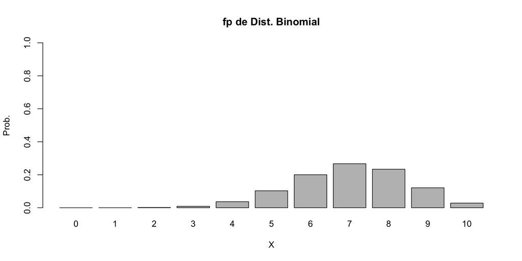

- **Função de Probabilidade de uma VA Contínua**

A função (densidade) de probabilidade de uma VA contínua X é a função $f: \mathbb{R} \rightarrow \mathbb{R}$ definda por:
$$\begin{equation*}
p(a \leq X \leq b) = \int_{a}^{b} f(x)dx
\end{equation*}$$

Condições:

$$\begin{align*}
f(x) &\geq 0, \\
\int_{-\infty}^{+\infty} f(x) &= 1
\end{align*}$$

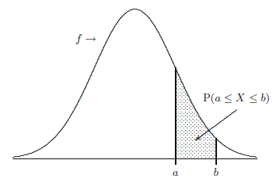

- É uma função definida para todo $y$ (resultado possível de uma variável aleatória)
- atribui probabilidades para todo $y$ (ou intervalo de $y$) possível.

## Calculando Probabilidades a partir de FDPs

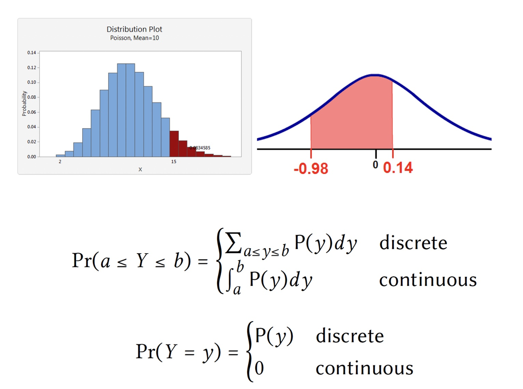

Por quê?

## Função de Distribuição Acumulada

**Definição**

A função de distribuição acumulada $F(\cdot)$ de uma VA $X$ é a função $F:\mathbb{R} \rightarrow [0,1]$ definida por:

$$F(a) = P(X \leq a)\,\,\, \text{para} \,\, -\infty \leq a \leq \infty$$

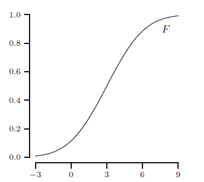

## Amostra Aleatória

**O que é uma Amostra Aleatória?**

Seja $X$ uma variável aleatória com distribuição de probabilidade desconhecida ou conhecida. Dizemos que $X_1, X_2, \ldots, X_n$ formam uma **amostra aleatória** de tamanho $n$ da população definida por $X$ se:

- Cada $X_i$ possui **a mesma distribuição** que $X$:

$$X_i \sim X \quad \text{(mesma função de distribuição)}$$

Em notação compacta:

$$X_1, X_2, \ldots, X_n \sim \text{i.i.d. } \sim F_X$$

(*i.i.d.* = *independent and identically distributed*)

- **Intuição: Por que isso importa?**

Imagine coletar dados sobre clientes de um banco. Se a coleta for **aleatória e independente**, as observações podem ser tratadas como uma amostra aleatória da população de interesse. Isso garante:

- **Imparcialidade estatística**
- Aplicabilidade de teoremas como a Lei dos Grandes Números e o Teorema Central do Limite
- Validade da inferência (estimação, intervalos, testes)

**Conexão com Monte Carlo**

**Exemplo:**

Se $X$ representa o tempo de espera em um call center e sabemos que segue uma distribuição exponencial com média de 5 minutos, então:

```r
amostra_aleatoria <- rexp(10000, rate = 1/5)
head(amostra_aleatoria)
```

```
[1] 3.2971254 0.1423412 7.7724356 1.7384721 1.2367716 2.0176016
```

gera uma amostra aleatória de tamanho 10.000 da população $X \sim \text{Exponencial}(5)$

## Lei dos Grandes Números

**O que diz a Lei dos Grandes Números?**

A **Lei dos Grandes Números (LGN)** afirma que:

> 📌 Quando repetimos um experimento aleatório muitas vezes de forma independente, a **média dos resultados observados** se aproxima da **média teórica** da variável.

🔹 Formulação Matemática

Se $X_1, X_2, \dots, X_n$ são variáveis aleatórias i.i.d. com valor esperado $\mu =E[X_i]$, então:

$$\bar{X}_n = \frac{1}{n} \sum_{i=1}^{n} X_i \xrightarrow[]{n \to \infty} \mu$$

👉 Isso significa: **a média amostral converge para a média populacional**.

🧠 Intuição com analogia

Imagine jogar uma moeda honesta milhares de vezes. A proporção de “caras” pode oscilar no começo, mas **com o tempo ela estabiliza perto de 0.5**.

🎯 A LGN garante esse comportamento para qualquer experimento aleatório com média finita.

💻 Exemplo em R

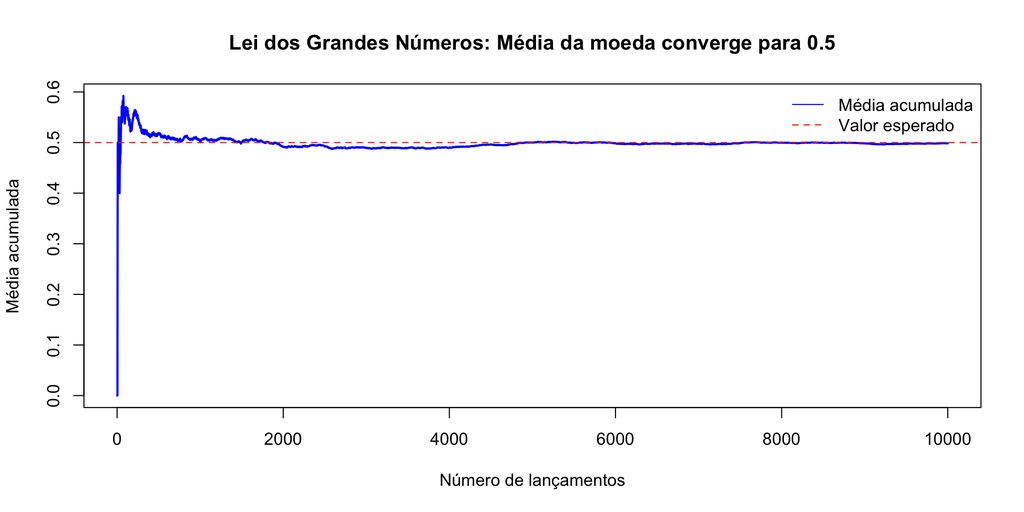

```r
# Simulando 10.000 lançamentos de moeda (0 = coroa, 1 = cara)
set.seed(42)
lancamentos <- sample(0:1, size = 10000, replace = TRUE)

# Média acumulada
media_acumulada <- cumsum(lancamentos) / (1:10000)

# Gráfico
plot(media_acumulada, type = "l", col = "blue", lwd = 2,
     main = "Lei dos Grandes Números: Média da moeda converge para 0.5",
     xlab = "Número de lançamentos", ylab = "Média acumulada")
abline(h = 0.5, col = "red", lty = 2)
legend("topright", legend = c("Média acumulada", "Valor esperado"),
       col = c("blue", "red"), lty = c(1, 2), bty = "n")
```

📌 Por que isso importa?

- **Fundamenta os métodos de Simulação de Monte Carlo**: estimativas pela média amostral
- **Base da indústria de Seguros**: permite calcular prêmios com base em médias históricas

## Funções de Probabilidade

**O que você deve saber sobre uma FP?**

- A **atribuição** de uma probabilidade ou densidade de probabilidade a todo valor concebível de $Y_i$.
- Os **princípios fundamentais**
- Como **usar** a expressão final (mas não necessariamente a derivação completa da expressão).
- Como **simular** a partir da densidade.
- Como **calcular** características da densidade, como seus “momentos”.
- Como **verificar** se a expressão final é de fato uma função de densidade adequada.

# Distribuições de Probabilidade de VA Discretas

## Distribuição de Bernoulli

**O que é uma Distribuição de Bernoulli?**

Os **Princípios fundamentais** do processo que gera $Y_i$ são tais que:

- $Y_i$ pode assumir 2 resultados **mutuamente exclusivos**, e;
- Os dois resultados são **exaustivos**

A função de probabilidade de uma distribuição de Bernoulli é:

$$P(X = x) =
\begin{cases}
\pi & \text{se } x = 1 \\
1 - \pi & \text{se } x = 0
\end{cases}$$

ou, de forma mais compacta:

$$P(X = x) = p^x(1 - p)^{1 - x} \,\,\, \text{para}\,\, x = {0,1}$$

A distribuição de Bernoulli é uma das distribuições discretas mais simples e fundamentais em estatística, descrevendo um experimento aleatório onde apenas dois resultados são possíveis, geralmente chamados de “sucesso” e “fracasso”, ou “1” e “0”.

## Características de uma Distribuição de Probabilidade

**Momentos Sumarizam Informação**

Uma distribuição de probabilidade pode conter **infinitos** valores possíveis de uma VA. Na prática, é impossível analisar cada valor possível de uma VA e suas respectivas probabilidades.

Por isso, precisamos de **medidas-resumo** que capturem as características essenciais da distribuição em poucos números interpretáveis.

**1. Tendência Central: Onde os Dados se Concentram?**

- **Valor Esperado**: Resume em um único número o “centro” da distribuição

**2. Variabilidade: Quantificando a Incerteza**

- **Variância e Desvio-Padrão**: Resumem a variabilidade da distribuição em uma medida

**3. Forma da Distribuição**

- **Assimetria e Curtose**: Resumem desvios do padrão normal
  - Assimetria: Medida de simetria da distribuição
  - Curtose: Medida de “achatamento” da distribuição
  - Ajudam a quantificar se eventos extremos são mais prováveis que o esperado

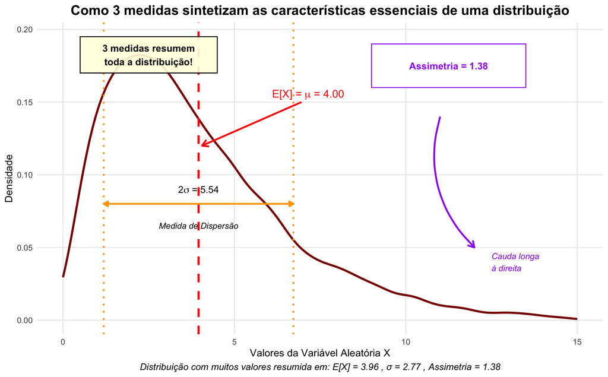

## Valor Esperado: Definição Formal

**Definição Matemática**

**Para uma VA Discreta:**

$$E[X] = \mu_X = \sum_{i} x_i \cdot P(X = x_i)$$

**Para uma VA Contínua:**

$$E[X] = \mu_X = \int_{-\infty}^{\infty} x \cdot f(x) \, dx$$

**Exemplo: Lançamento de um dado honesto**

$$\begin{align}
E[X] &= \sum_{i=1}^{6} x_i \cdot P(X = x_i) \\
&= 1 \cdot \frac{1}{6} + 2 \cdot \frac{1}{6} + ... + 6 \cdot \frac{1}{6}\\
&= \frac{1}{6}(1 + 2 + 3 + 4 + 5 + 6) \\
&= \frac{21}{6} = 3.5
\end{align}$$

**Interpretação**: Em média, esperamos obter 3.5 se lançarmos um dado muitas vezes.

## Propriedades do Valor Esperado

**Propriedades Matemáticas Fundamentais**

**1. Linearidade**: $E[aX + bY] = aE[X] + bE[Y]$

**Exemplo - Cateira de Investimentos:**

- 30% em ações (retorno esperado: 12%)
- 70% em renda fixa (retorno esperado: 5%)

$$E[R_{carteira}] = 0.3 \times 12\% + 0.7 \times 5\% = 7.1\%$$

**2. Valor esperado de constante**: $E[c] = c$

**3. Independência**: Se X e Y independentes, $E[XY] = E[X] \cdot E[Y]$

**4. Função não-linear**: $E[g(X)] \neq g(E[X])$ em geral

**Aplicação**: Estas propriedades simplificam cálculos complexos em finanças

## Variância

**Definição**

A variância $V(X)$ de uma variável aleatória $X$ mede a dispersão dos valores de $X$ em torno do seu valor esperado.

Para uma VA Discreta:

$$V(X) = \sigma_{X}^2 = \sum_{i} (x_i - E(X))^2 P(X = x_i)$$

Para uma VA Contínua:

$$V(X) = \sigma_{X}^2 = \int_{-\infty}^{\infty} (x - E(X))^2 f(x) \, dx$$

## Variância = Variação/Risco

## Variância: Propriedades Básicas

**Propriedades**

- **Variância de uma Constante**

Se $c$ é uma constante, então a variância de $c$ é zero:

$\boxed{V(c) = 0}$

- **Adição de uma Constante**

Se $X$ é uma variável aleatória e $c$ é uma constante, a variância de $X + c$ é igual à variância de $X$:

$\boxed{V(X + c) = V(X)}$

- **Variância de uma Constante Multiplicada por uma Variável Aleatória**

Para qualquer variável aleatória $X$ e uma constante $a$, a variância de $aX$ é dada por:

$\boxed{V(aX) = a^2 V(X)}$

- **Variância da Soma de Variáveis Aleatórias**

Para variáveis aleatórias $X$ e $Y$ não necessariamente independentes, a variância da soma é:

$\boxed{V(X + Y) = V(X) + V(Y) + 2\text{Cov}(X, Y)}$

onde $Cov(X, Y)$ é a covariância entre $X$ e $Y$.

- **Variância da Soma de Variáveis Aleatórias Independentes**

Para variáveis aleatórias $X$ e $Y$ independentes:

$\boxed{V(X + Y) = V(X) + V(Y)}$

- **Variância da Diferença de Variáveis Aleatórias Independentes**

Para variáveis aleatórias $X$ e $Y$ independentes:

$\boxed{V(X - Y) = V(X) + V(Y)}$

## Propriedades da Variância

**Propriedades em R**

```r
# Exemplo das propriedades
set.seed(123)
investimento <- rnorm(1000, mean = 0.05, sd = 0.12)  # Retorno 5%, vol 12%

# Propriedade 1: V(X + constante) = V(X)
# Adicionar uma constante não altera o risco
taxa <- 0.02
var(investimento)
```

```
[1] 0.01416181
```

```r
var(investimento + taxa)  # Variância igual
```

```
[1] 0.01416181
```

```r
# Propriedade 2: V(a*X) = a²*V(X)
# Dobrar o investimento quadruplica o risco
dobro_investimento <- 2 * investimento
var(investimento)
```

```
[1] 0.01416181
```

```r
var(dobro_investimento)  # 4 vezes maior
```

```
[1] 0.05664723
```

```r
2^2 * var(investimento)  # Confirmação teórica
```

```
[1] 0.05664723
```

## Desvio-Padrão

**Definição**

O desvio-padrão ($\sigma$) de uma VA é a raiz quadrada da variância e fornece uma medida da dispersão dos valores de $X$ em torno do seu valor esperado na mesma unidade de $X$.

$$\sigma = \sqrt{V(X)}$$

Por exemplo, se a unidade de $X$ for R$ (reais), o desvio-padrão também será em reais, enquanto a variância será em reais ao quadrado (R$$^2$).

## Coeficientes de Assimetria e Curtose

**Definições**

**Coeficiente de Assimetria (Skewness)**:

$$\text{Assimetria}(X) = E\left[\left(\frac{X - \mu}{\sigma}\right)^3\right]$$

**Coeficiente de Curtose (Kurtosis)**:

$$\text{Curtose}(X) = E\left[\left(\frac{X - \mu}{\sigma}\right)^4\right]$$

**Interpretação**:

- Assimetria = 0: distribuição simétrica
- Assimetria à direita (positiva) > 0: cauda mais longa à direita
- Assimetria à esquerda (negativa) < 0: cauda mais longa à esquerda
- Curtose = 3: curtose normal (mesocúrtica)
- Curtose > 3: distribuição mais pontiaguda (leptocúrtica)
- Curtose < 3: distribuição mais achatada (platicúrtica)

## Coeficientes de Assimetria e Curtose

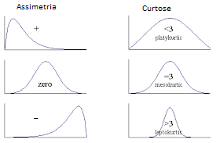

## Momentos da Distribuição de Bernoulli

**Momentos**

- **Valor Esperado (Média)**

$$\begin{align}
E(Y) &= \sum_{i=1}^{n} x_i P(Y = y_i) \\
&= 0 \times P(Y = 0) + 1 \times P(Y = 1) \\
&= 0 \times (1 - \pi) + 1 \times \pi \\
&= \pi
\end{align}$$

- **Variância**

$$\begin{align}
V(Y) &= E[(Y - E(Y))^2] \,\,\, \text{definição}\\
&= E(Y^2) - E(Y)^2\\
&= E(Y^2) - \pi^2
\end{align}$$

Como podemos calcular $E(Y^2)$?

## Valor Esperado de Funções de Variáveis Aleatórias

**Valor Esperado de Funções de Variáveis Aleatórias**

$$\begin{align}
E(g(Y)) &= \sum_{\text{todo y}} g(y)P(Y) \,\,\, \text{(VA discreta)}\\
E(g(Y)) &= \int_{-\infty}^{\infty}g(y)f(y)dy \,\,\, \text{(VA contínua)}
\end{align}$$

Em nosso caso:

$$\begin{align}
E(Y^2) &= \sum_{\text{todo y}} g(y)P(Y) \\
&= \sum_{\text{todo y}} Y^2 P(Y) \\
&= 0^2 \times P(Y = 0) + 1^2 \times P(Y = 1) \\
&= 0^2 \times (1 - \pi) + 1^2 \times \pi \\
&= \pi
\end{align}$$

## Variância de uma VA com distribuição de Bernoulli

**Derivação da Variância**

Usando o resultado anterior:

$$\begin{align}
V(Y) &= E[(Y - E(Y))^2] \,\,\, \text{definição}\\
&= E(Y^2) - E(Y)^2\\
&= E(Y^2) - \pi^2 \\
&= \pi - \pi^2 \\
&= \pi(1-\pi)
\end{align}$$

Isto faz sentido:

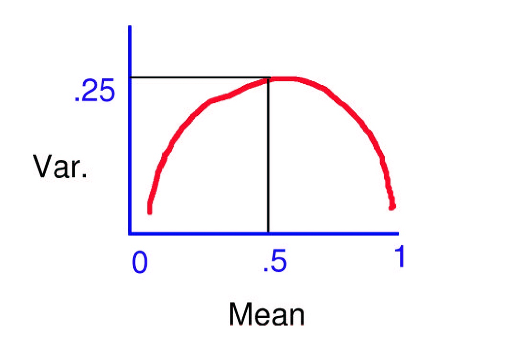

- Para uma distribuição de Bernoulli, a máxima dispersão ocorre quando os dois resultados possíveis (sucesso e fracasso) são igualmente prováveis, ou seja, quando $\pi = 0.5$.
- Isso porque, nesse caso, há a maior incerteza possível sobre o resultado de um ensaio
- A variável aleatória é tão provável de ser 1 quanto é de ser 0, o que maximiza a dispersão dos valores em torno da média.

## Como simular uma VA com distribuição de Bernoulli

**Simulação de uma VA Bernoulli**

- Para simular uma variável aleatória com distribuição de Bernoulli em R, você pode usar a função `rbinom()`.
- A distribuição de Bernoulli é um caso especial da distribuição binomial, onde o número de ensaios ($n$) é igual a 1.
- A função `rbinom()` tem três argumentos principais:
- `n`: número de observações (ou simulações) que você deseja gerar.
- `size`: número de ensaios, que para uma distribuição de Bernoulli é sempre 1.
- `prob`: probabilidade de sucesso em cada ensaio.

Para simular uma variável aleatória de Bernoulli com uma probabilidade de sucesso de 0.5 (50%) para 10 observações:

```r
# Fixa a semente para reprodutibilidade
set.seed(123)

# Simula 10 observações de uma VA Bernoulli
simulacao_bernoulli <- rbinom(n = 10, size = 1, prob = 0.5)
simulacao_bernoulli
```

```
 [1] 0 1 0 1 1 0 1 1 1 0
```

## Distribuição Binomial

**O que é uma Distribuição Binomial?**

Os **Princípios Primeiros** sobre o processo que gera $Y_i$ são tais que:

- $n$ ensaios *i.i.d* de Bernoulli: $y_1,\ldots,y_n$
- Os ensaios são **indepentendes**
- Os ensaios são **identicamente distribuídos**
- Observamos: $Y = \sum_{i=1}^{n} y_i$

**Função de Probabilidade**

$$P(Y = y|\pi) = \binom{n}{y} \pi^k (1-\pi)^{n-k}$$
Explicação:

- $\binom{n}{y}$ por que ambos, $(1 0 1)$ e $(1 1 0)$ produzem $y = 2$
- $\pi^y$ porque $y$ sucessos com probabilidade $\pi$ cada (produto tomada devido à independência)
- $(1 - \pi)^{n-y}$ porque $n-y$ fracassos em com probabilidade $(1 - \pi)$ cada.

**Momentos**:

Valor Esperado (Média): $E(Y) = n\pi$

## Como simular uma VA com distribuição Binomial?

**Simulação de uma VA Binomial**

- Como vimos, podemos usar a função `rbinom()`, que tem três argumentos principais:
- `n`: número de observações (ou simulações) que você deseja gerar.
- `size`: número de ensaios, que para uma distribuição de Bernoulli é sempre 1.
- `prob`: probabilidade de sucesso em cada ensaio.

Por exemplo, para simular 100 observações de uma variável aleatória Binomial, onde cada observação representa o número de sucessos em 10 ensaios, com uma probabilidade de sucesso de 0.5:

```r
# Fixa a semente para reprodutibilidade
set.seed(123)

# Simula 100 observações de uma VA Binomial
simulacao_binomial <- rbinom(n = 100, size = 10, prob = 0.5)
simulacao_binomial
```

```
  [1] 4 6 5 7 7 2 5 7 5 5 8 5 6 5 3 7 4 2 4 8 7 6 6 9 6 6 5 5 4 3 8 7 6 6 2 5 6
 [38] 4 4 4 3 5 5 4 3 3 4 5 4 7 2 5 6 3 5 4 3 6 7 4 6 3 5 4 6 5 6 6 6 5 6 6 6 0
 [75] 5 4 5 5 4 3 4 6 5 6 3 5 8 7 7 4 3 6 4 6 4 4 6 3 5 5
```

## Atualizando os Repositórios

**Instruções**

1. No terminal do RStudio, verifique quais arquivos/pastas foram modificados ou criados com:

```bash
git status
```

2. Você pode adicionar todos os arquivos de uma vez com:

```bash
git add .
```

3. Execute git status novamente para confirmar que todos os arquivos foram adicionados (aparecerão em verde sob “*Changes to be committed*”):

```bash
git status
```

4. Se tudo estiver em verde, faça um commit com uma mensagem descritiva:

```bash
git commit -m "atualizacoes aula 8"
```

5. Se algum arquivo ou pasta ainda aparecer em vermelho após o segundo git status, adicione as pastas/arquivos um por um:

```bash
git add relatorios/08-relatorio/08-relatorio.qmd
```

6. Execute git status novamente e faça o commit quando todos os arquivos estiverem em verde:

```bash
git commit -m "atualizacoes aula 8"
```

7. Envie o repositório local atualizado para o GitHub:

```bash
git push origin main
```